# Preprocessing Experiment 2 data

Bodo Winter & Greg Woodin

13/10/2018

# Continuous analysis of Experiment 2

```r
library(tidyverse)  # for data processing
library(stringr)    # for data processing
library(lme4)   # for mixed models
library(afex)   # for mixed models
library(lsr)    # for calculating Cramer's V

source('../scripts/functions.R')
source('../scripts/predict.glmm.R')

E2l <- read_csv("../data/E2_long.csv")
E2l %>% print(n = 6, width = Inf)
```

```
## # A tibble: 732 x 10
##   Subject Hand  Gender Condition TimeOrder ValenceOrder QuantityOrder
##     <int> <chr> <chr>  <chr>         <int>        <int>         <int>
## 1       1 Right Female Time              3            1             2
## 2       1 Right Female Time              3            1             2
## 3       1 Right Female Time              3            1             2
## 4       1 Right Female Time              3            1             2
## 5       2 Right Male   Time              2            3             1
## 6       2 Right Male   Time              2            3             1
##   Word         x     y
##   <chr>    <int> <int>
## 1 Earliest  -170   242
## 2 Earlier    -59   174
## 3 Later       24   123
## 4 Latest     112    55
## 5 Earliest  -119   252
## 6 Earlier   -121   266
## # ... with 726 more rows
```

Preliminary data wrangling:

```r
# Centre and Z-score by participant:
all_subs <- unique(E2l$Subject)
E2l$x_c <- NA
E2l$y_c <- NA
E2l$x_z <- NA
E2l$y_z <- NA
for (i in all_subs) {
  df <- filter(E2l, Subject == i)

  # Center:
    E2l[E2l$Subject == i, ]$x_c <- df$x - mean(df$x)
    E2l[E2l$Subject == i, ]$y_c <- df$y - mean(df$y)

    # Standardize:
    E2l[E2l$Subject == i, ]$x_z <- (df$x - mean(df$x)) / sd(df$x)
    E2l[E2l$Subject == i, ]$y_z <- (df$y - mean(df$y))  / sd(df$y)
}

# Add a numerical identifier for earliest/least/worst = 1 etc.:
E2l$Polarity <- rep(1:4, 3 * 61)
E2l <- mutate(E2l,
              Polarity_c = Polarity - mean(Polarity),
              Polarity_ord = as.ordered(Polarity))

# Create a factor for consistent plotting:
mylevs <- c('Time', 'Quantity', 'Valence')
E2l <- mutate(E2l,
              Cond_fac = factor(Condition,
                                levels = mylevs))
```

## Analysis of range (measure of axis use)

Construct range aggregate data frame:

```r
range_agr <- E2l %>%
  group_by(Subject, Cond_fac) %>%
  summarize(min_x = min(x), max_x = max(x),
            min_y = min(y), max_y = max(y))
range_agr <- mutate(range_agr,
                    x_diff = max_x - min_x,
                    y_diff = max_y - min_y)
```

Look at x- and y-axis spread of markings for each task:

```r
range_agr %>% group_by(Cond_fac) %>%
    summarize(xrange = mean(x_diff),
        yrange = mean(y_diff))
```

```
## # A tibble: 3 x 3
##   Cond_fac xrange yrange
##   <fct>     <dbl>  <dbl>
## 1 Time       200.   88.1
## 2 Quantity   124.  132.
## 3 Valence    162.  133.
```

Make into long format for double plot:

```r
range_long <- range_agr %>%
  select(-min_x, -max_x, -min_y, -max_y) %>%
  gather(key = Axis,
         value = Range, -Subject, -Cond_fac)
```

Make a public-ready boxplot of the ranges:

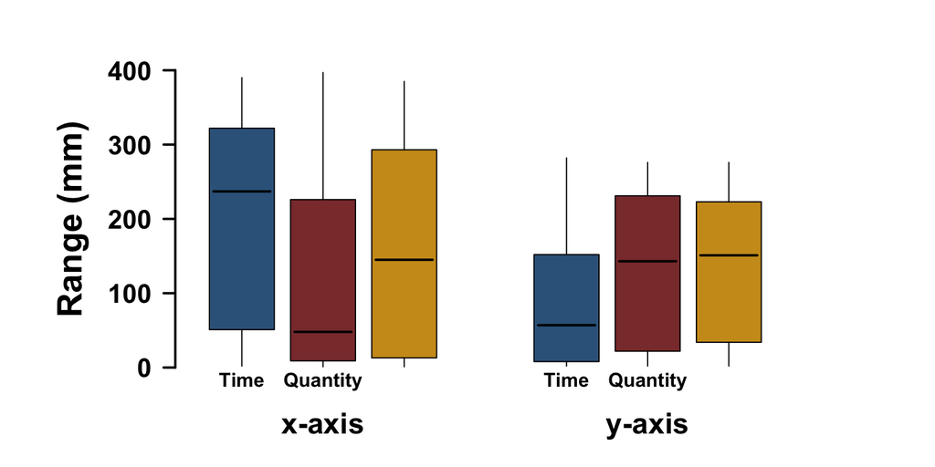

```r
# Box values to be plotted:

x_box <- boxplot(x_diff ~ Cond_fac,
                 data = range_agr, plot = FALSE)
y_box <- boxplot(y_diff ~ Cond_fac,
                 data = range_agr, plot = FALSE)

# Plotting parameters:

xfac <- 0.1
mycols <- c('steelblue4', 'indianred4', 'goldenrod3')

# The actual plot:

quartz('', 9, 4)
par(mai = c(0.75, 1.5, 0.5, 0.5))
emptyplot(xlim = c(0, 8), ylim = c(0, 400))
axis(side = 2, at = seq(0, 400, 100),
    font = 2, las = 2, cex.axis = 1.35, lwd = 2)
mtext(text = 'Range (mm)', side = 2, line = 3.8,
    font = 2, cex = 1.75)
axis(side = 1, at = seq(0.5, 2.5, 1),
    labels = c('Time', 'Quantity', 'Valence'),
    font = 2, cex.axis = 1, line = -1.5, tick = FALSE)
axis(side = 1, at = c(1.5, 5.5),
    labels = c('x-axis', 'y-axis'),
    font = 2, cex.axis = 1.5, line = 0.5, tick = FALSE)
for (i in 1:3) {
    rect(xleft = i - 1 + xfac, xright = i - xfac,
        ybottom = x_box$stats[2, i],
        ytop = x_box$stats[4, i],
        col = mycols[i])
    segments(x0 = i - 1 + xfac + 0.05, x1 = i - xfac - 0.05,
        y0 = x_box$stats[3, i], lwd = 2)
    segments(x0 = seq(0.5, 2.5, 1)[i],
        y0 = x_box$stats[4, i],
        y1 = x_box$stats[5, i])
    segments(x0 = seq(0.5, 2.5, 1)[i],
        y1 = x_box$stats[2, i],
        y0 = x_box$stats[1, i])
    }
axis(side = 1, at = seq(0.5, 2.5, 1) + 4,
    labels = c('Time', 'Quantity', 'Valence'),
    font = 2, cex.axis = 1, line = -1.5, tick = FALSE)
for (i in 1:3) {
    rect(xleft = i - 1 + xfac + 4, xright = i - xfac + 4,
        ybottom = y_box$stats[2, i],
        ytop = y_box$stats[4, i],
        col = mycols[i])
    segments(x0 = i - 1 + xfac + 0.05 + 4, x1 = i - xfac - 0.05 + 4,
        y0 = y_box$stats[3, i], lwd = 2)
    segments(x0 = seq(0.5, 2.5, 1)[i] + 4,
        y0 = y_box$stats[4, i],
        y1 = y_box$stats[5, i])
    segments(x0 = seq(0.5, 2.5, 1)[i] + 4,
        y1 = y_box$stats[2, i],
        y0 = y_box$stats[1, i])
    }
```

## Linear mixed effects model analysis:

Separate models:

```r
# Likelihood ratio test for x-axis model:

mixed(x_diff ~ Cond_fac + (1|Subject),
      data = range_agr, REML = FALSE, method = 'LRT')
```

```
## Contrasts set to contr.sum for the following variables: Cond_fac
```

```
## Fitting 2 (g)lmer() models:
## [..]
```

```
## Mixed Model Anova Table (Type 3 tests, LRT-method)
##
## Model: x_diff ~ Cond_fac + (1 | Subject)
## Data: range_agr
## Df full model: 5
##     Effect df     Chisq p.value
## 1 Cond_fac  2 19.56 ***  <.0001
## ---
## Signif. codes:  0 '***' 0.001 '**' 0.01 '*' 0.05 '+' 0.1 ' ' 1
```

```r
summary(x_mdl <- lmer(x_diff ~ Cond_fac +
                        (1|Subject),
                      data = range_agr, REML = FALSE))
```

```
## Linear mixed model fit by maximum likelihood . t-tests use
##   Satterthwaite's method [lmerModLmerTest]
## Formula: x_diff ~ Cond_fac + (1 | Subject)
##    Data: range_agr
##
##      AIC      BIC   logLik deviance df.resid
##   2274.8   2290.8  -1132.4   2264.8      178
##
## Scaled residuals:
##      Min       1Q   Median       3Q      Max
## -2.18151 -0.66498 -0.00154  0.57531  2.31831
##
## Random effects:
##  Groups   Name        Variance Std.Dev.
##  Subject  (Intercept) 10371    101.84
##  Residual              8239     90.77
## Number of obs: 183, groups:  Subject, 61
##
## Fixed effects:
##                  Estimate Std. Error     df t value Pr(>|t|)
## (Intercept)        200.10      17.47 112.89  11.456  < 2e-16 ***
## Cond_facQuantity   -75.70      16.44 122.00  -4.606 1.02e-05 ***
## Cond_facValence    -37.67      16.44 122.00  -2.292   0.0236 *
## ---
## Signif. codes:  0 '***' 0.001 '**' 0.01 '*' 0.05 '.' 0.1 ' ' 1
##
## Correlation of Fixed Effects:
##             (Intr) Cnd_fQ
## Cnd_fcQntty -0.471
## Cond_fcVlnc -0.471  0.500
```

```r
# Likelihood ratio test for y-axis model:

mixed(y_diff ~ Cond_fac + (1|Subject),
      data = range_agr, REML = FALSE, method = 'LRT')
```

```
## Contrasts set to contr.sum for the following variables: Cond_fac
```

```
## Fitting 2 (g)lmer() models:
## [..]
```

```
## Mixed Model Anova Table (Type 3 tests, LRT-method)
##
## Model: y_diff ~ Cond_fac + (1 | Subject)
## Data: range_agr
## Df full model: 5
##     Effect df     Chisq p.value
## 1 Cond_fac  2 16.60 ***   .0002
## ---
## Signif. codes:  0 '***' 0.001 '**' 0.01 '*' 0.05 '+' 0.1 ' ' 1
```

```r
summary(y_mdl <- lmer(y_diff ~ Cond_fac +
                        (1|Subject),
                      data = range_agr, REML = FALSE))
```

```
## Linear mixed model fit by maximum likelihood . t-tests use
##   Satterthwaite's method [lmerModLmerTest]
## Formula: y_diff ~ Cond_fac + (1 | Subject)
##    Data: range_agr
##
##      AIC      BIC   logLik deviance df.resid
##   2152.6   2168.6  -1071.3   2142.6      178
##
## Scaled residuals:
##      Min       1Q   Median       3Q      Max
## -2.63993 -0.62656  0.02795  0.65781  2.10306
##
## Random effects:
##  Groups   Name        Variance Std.Dev.
##  Subject  (Intercept) 4392     66.27
##  Residual             4515     67.19
## Number of obs: 183, groups:  Subject, 61
##
## Fixed effects:
##                  Estimate Std. Error     df t value Pr(>|t|)
## (Intercept)         88.08      12.08 123.13   7.290 3.28e-11 ***
## Cond_facQuantity    43.69      12.17 122.00   3.591 0.000476 ***
## Cond_facValence     45.15      12.17 122.00   3.711 0.000312 ***
## ---
## Signif. codes:  0 '***' 0.001 '**' 0.01 '*' 0.05 '.' 0.1 ' ' 1
##
## Correlation of Fixed Effects:
##             (Intr) Cnd_fQ
## Cnd_fcQntty -0.503
## Cond_fcVlnc -0.503  0.500
```

Combined model testing the interaction:

```r
summary(all_mdl <- lmer(Range ~ Cond_fac * Axis + (1|Subject),
    data = range_long, REML = FALSE))
```

```
## Linear mixed model fit by maximum likelihood . t-tests use
##   Satterthwaite's method [lmerModLmerTest]
## Formula: Range ~ Cond_fac * Axis + (1 | Subject)
##    Data: range_long
##
##      AIC      BIC   logLik deviance df.resid
##   4524.0   4555.2  -2254.0   4508.0      358
##
## Scaled residuals:
##      Min       1Q   Median       3Q      Max
## -1.97316 -0.89498  0.00411  0.83303  2.18976
##
## Random effects:
##  Groups   Name        Variance Std.Dev.
##  Subject  (Intercept)  2279     47.74
##  Residual             11479    107.14
## Number of obs: 366, groups:  Subject, 61
##
## Fixed effects:
##                             Estimate Std. Error      df t value Pr(>|t|)
## (Intercept)                   200.10      15.02  321.85  13.324  < 2e-16
## Cond_facQuantity              -75.70      19.40  305.00  -3.902 0.000117
## Cond_facValence               -37.67      19.40  305.00  -1.942 0.053077
## Axisy_diff                   -112.02      19.40  305.00  -5.774 1.91e-08
## Cond_facQuantity:Axisy_diff   119.39      27.44  305.00   4.352 1.85e-05
## Cond_facValence:Axisy_diff     82.82      27.44  305.00   3.019 0.002753
##
## (Intercept)                 ***
## Cond_facQuantity            ***
## Cond_facValence             .
## Axisy_diff                  ***
## Cond_facQuantity:Axisy_diff ***
## Cond_facValence:Axisy_diff  **
## ---
## Signif. codes:  0 '***' 0.001 '**' 0.01 '*' 0.05 '.' 0.1 ' ' 1
##
## Correlation of Fixed Effects:
##             (Intr) Cnd_fQ Cnd_fV Axsy_d C_Q:A_
## Cnd_fcQntty -0.646
## Cond_fcVlnc -0.646  0.500
## Axisy_diff  -0.646  0.500  0.500
## Cnd_fcQn:A_  0.457 -0.707 -0.354 -0.707
## Cnd_fcVl:A_  0.457 -0.354 -0.707 -0.707  0.500
```

```r
mixed(Range ~ Cond_fac * Axis + (1 + Axis|Subject),
    data = range_long, REML = FALSE, method = 'LRT')
```

```
## Contrasts set to contr.sum for the following variables: Cond_fac
```

```
## Fitting 4 (g)lmer() models:
## [....]
```

```
## Mixed Model Anova Table (Type 3 tests, LRT-method)
##
## Model: Range ~ Cond_fac * Axis + (1 + Axis | Subject)
## Data: range_long
## Df full model: 10
##          Effect df     Chisq p.value
## 1      Cond_fac  2 25.98 ***  <.0001
## 2          Axis  1    5.46 *     .02
## 3 Cond_fac:Axis  2 33.40 ***  <.0001
## ---
## Signif. codes:  0 '***' 0.001 '**' 0.01 '*' 0.05 '+' 0.1 ' ' 1
```

Get predictions:

```r
source('../scripts/predict.glmm.R')
all_types <- unique(range_long$Cond_fac)
all_axis <- unique(range_long$Axis)
newdata <- expand.grid(all_types, all_axis) %>%
  rename(Cond_fac = Var1, Axis = Var2) %>%
  arrange(Cond_fac)
predict.glmm(all_mdl, newdata = newdata) %>%
  mutate(Range = round(Range))
```

```
##   Cond_fac   Axis Range       SE       UB        LB
## 1     Time x_diff   200 15.01808 229.5338 170.66292
## 2     Time y_diff    88 15.01808 117.5174  58.64653
## 3 Quantity x_diff   124 15.01808 153.8289  94.95801
## 4 Quantity y_diff   132 15.01808 161.2059 102.33505
## 5  Valence x_diff   162 15.01808 191.8617 132.99079
## 6  Valence y_diff   133 15.01808 162.6649 103.79407
```

## Categorical analysis

Load the categorical data:

```r
E2 <- read_csv("../data/E2cat_long.csv")
E2 %>% print(n = 6, width = Inf)
```

```
## # A tibble: 183 x 10
##   Subject Hand  Gender Condition ConsistentAxis AxisChoice
##     <int> <chr> <chr>  <chr>     <chr>          <chr>
## 1       1 Right Female Time      Yes            diagonal
## 2       1 Right Female Quantity  Yes            vertical
## 3       1 Right Female Valence   Yes            vertical
## 4       2 Right Male   Time      No             horizontal
## 5       2 Right Male   Quantity  No             horizontal
## 6       2 Right Male   Valence   No             <NA>
##   AxisChoiceDetailed           DirectionDetailed     Horizontal
##   <chr>                        <chr>                 <chr>
## 1 diagonal                     up-left to down-right left-to-right
## 2 vertical                     down to up            <NA>
## 3 vertical                     down to up            <NA>
## 4 other / primarily horizontal <NA>                  <NA>
## 5 other / primarily horizontal <NA>                  <NA>
## 6 other                        <NA>                  <NA>
##   Vertical
##   <chr>
## 1 up-to-down
## 2 down-to-up
## 3 down-to-up
## 4 <NA>
## 5 <NA>
## 6 <NA>
## # ... with 177 more rows
```

```r
E2_short <- read_csv("../data/E2_cat.csv")
E2_short %>% print(n = 6, width = Inf)
```

```
## # A tibble: 61 x 22
##   Subject Hand  Gender TimeOrder TimeAxis TimeRepresentation
##     <int> <chr> <chr>      <int> <chr>    <chr>
## 1       1 Right Female         3 Yes      Diagonal
## 2       2 Right Male           2 No       Other / primarily horizontal
## 3       3 Right Male           2 Yes      Horizontal
## 4       4 Right Female         1 Yes      Vertical
## 5       5 Right Male           2 Yes      Horizontal
## 6       6 Right Female         1 Yes      Vertical
##   TimeConsistent TimeDirection         TimeQuadrant        QuantityOrder
##   <chr>          <chr>                 <chr>                       <int>
## 1 Yes            Up-left to down-right Up-left, down-right             2
## 2 No             n/a                   Up-left                         1
## 3 Yes            Left to right         n/a                             1
## 4 Yes            Up to down            Up-left, down-left              3
```

[output cut: 35 more lines]

Preliminary data wrangling:

```r
# Recode AxisChoice as 'other' and AxisChoiceDetailed as ‘other / no pattern’ if DirectionDetailed == NA:
E2[is.na(E2$DirectionDetailed), ]$AxisChoice <- 'other'
E2[is.na(E2$DirectionDetailed), ]$AxisChoiceDetailed <- 'other / no pattern'

# Find out number of participants:
print(ntot <- length(unique(E2$Subject)))
```

```
## [1] 61
```

```r
# Change NAs in AxisChoice to 'other':
E2[is.na(E2$AxisChoice), ]$AxisChoice <- 'other'
```

## Axis Consistency

Find out how many participants used an axis to structure their response:

```r
E2 <- mutate(E2,
    DominantOrientation = ifelse(AxisChoice == 'other', 'none', 'some'))
table(E2$DominantOrientation)
```

```
##
## none some
##   84   99
```

```r
prop.table(table(E2$DominantOrientation))
```

```
##
##      none      some
## 0.4590164 0.5409836
```

Look at consistent axis choice across tasks:

```r
# Descriptive stats:
E2 %>% group_by(Condition, DominantOrientation) %>% count() %>%
    mutate(Proportion = n / ntot,
        Percentage = Proportion * 100)
```

```
## # A tibble: 6 x 5
## # Groups:   Condition, DominantOrientation [6]
##   Condition DominantOrientation     n Proportion Percentage
##   <chr>     <chr>               <int>      <dbl>      <dbl>
## 1 Quantity  none                   26      0.426       42.6
## 2 Quantity  some                   35      0.574       57.4
## 3 Time      none                   28      0.459       45.9
## 4 Time      some                   33      0.541       54.1
## 5 Valence   none                   30      0.492       49.2
## 6 Valence   some                   31      0.508       50.8
```

```r
# Perform a Chi-square test on this:
E2_tab <- with(E2, table(Condition, DominantOrientation))
chisq.test(E2_tab)
```

```
##
##  Pearson's Chi-squared test
##
## data:  E2_tab
## X-squared = 0.52814, df = 2, p-value = 0.7679
```

```r
cramersV(E2_tab)    # small = 0.1, medium = 0.3, large = 0.8
```

```
## [1] 0.05372153
```

Look at how many different axis choices participants made across the three tasks:

```r
per_p <- apply(select(E2_short, TimeRepresentation, QuantityRepresentation, ValenceRepresentation), 1, table)
E2_short$N_axes <- sapply(per_p, length)
print(per_p <- table(E2_short$N_axes))
```

```
##
##  1  2  3
## 30 23  8
```

```r
prop.table(per_p) * 100
```

```
##
##        1        2        3
## 49.18033 37.70492 13.11475
```

# Dominant Orientation

Find numbers and percentages of people who responded horizontally, vertically or diagonally for quantity, time and valence tasks:

```r
# Re-order categorical variables:
E2 <- mutate(E2,
    Condition_fac = factor(Condition, levels = c('Quantity', 'Time', 'Valence')),
    AxisChoice_fac = factor(AxisChoice,
        levels = c('horizontal', 'vertical', 'diagonal', 'other')))

# Descriptive stats:
E2_xtab <- with(E2, table(Condition, AxisChoice))
(E2_xtab <- E2_xtab[, colnames(E2_xtab) != 'other'])
```

```
##           AxisChoice
## Condition  diagonal horizontal vertical
##   Quantity        3         11       21
##   Time            3         22        8
##   Valence         4         11       16
```

```r
prop.table(E2_xtab, 1) * 100
```

```
##           AxisChoice
## Condition   diagonal horizontal  vertical
##   Quantity  8.571429  31.428571 60.000000
##   Time      9.090909  66.666667 24.242424
##   Valence  12.903226  35.483871 51.612903
```

```r
colnames(E2_xtab) <- c('Diagonal', 'Horizontal', 'Vertical')    # capitalize
E2_xtab <- E2_xtab[, c('Horizontal', 'Vertical', 'Diagonal')]   # re-order
E2_xtab <- E2_xtab[c('Time', 'Quantity', 'Valence'), ]
```

Perform a Chi-square test on this and get Pearson’s standardised residuals and Cramer’s V:

```r
print(E2_chisq <- chisq.test(E2_xtab))  # violates independence
```

```
##
##  Pearson's Chi-squared test
##
## data:  E2_xtab
## X-squared = 11.071, df = 4, p-value = 0.02578
```

```r
E2_chisq$stdres # violates independence
```

```
##           AxisChoice
## Condition  Horizontal   Vertical   Diagonal
##   Time      3.1464265 -2.9972209 -0.2358346
##   Quantity -1.9273582  2.1494185 -0.3734861
##   Valence  -1.2114551  0.8308851  0.6247205
```

```r
cramersV(E2_xtab)   # small = 0.1, medium = 0.3, large = 0.8
```

```
## [1] 0.2364578
```

Calculate Shannon entropy:

```r
(entropies <- round(apply(E2_xtab, MARGIN = 1, FUN = entropy), 2))
```

```
##     Time Quantity  Valence
##     1.20     1.27     1.40
```

## Sanity checks for independence violation

Run loop with random sample of data points from unique participants 1000 times:

```r
nsim <- 1000
xchisq <- numeric(nsim)

alltabs <- vector('list', length = nsim)

E2sub <- filter(E2, AxisChoice != 'other')

set.seed(42)
for (i in 1:nsim) {

  # Shuffle participants:

  xshuffled <- sample_n(E2sub, size = nrow(E2sub))

  # Get rid of duplicates:

  xshuffled <- filter(xshuffled,
                      !duplicated(Subject))

  xdata <- table(xshuffled$Condition,
                 xshuffled$AxisChoice)
    if (any(is.na(xdata))) xdata[is.na(xdata)] <- 0
    alltabs[[i]] <- xdata

    # Save the Chisquare value:
    suppressWarnings(this_chisq <- chisq.test(xdata))
    xchisq[i] <- this_chisq$statistic

    # Notify:
    if (i %% 100 == 0) cat(paste0(i, '\n'))
    }
```

```
## 100
## 200
## 300
## 400
## 500
## 600
## 700
## 800
## 900
## 1000
```

```r
# Significance threshold for df = 4 and a = 0.05:
chisq_crit <- qchisq(0.05, 4, lower.tail = FALSE)
sum(xchisq < chisq_crit)
```

```
## [1] 846
```

```r
sum(1 - pchisq(xchisq, df = 4) > 0.05)  # check
```

```
## [1] 846
```

```r
mean(xchisq)
```

```
## [1] 6.254303
```

```r
1 - pchisq(mean(xchisq), df = 4)    # significance of average Chi-Square value
```

```
## [1] 0.1809447
```

To double-check, perform a logistic mixed model of horizontal versus vertical:

```r
E2_nodiag <- filter(E2, AxisChoice %in% c('horizontal', 'vertical'))
E2_nodiag <- mutate(E2_nodiag,
                    AxisChoice = factor(AxisChoice))

mymdl <- glmer(AxisChoice ~ Condition + (1|Subject),
    data = E2_nodiag, family = 'binomial')

summary(mymdl)
```

```
## Generalized linear mixed model fit by maximum likelihood (Laplace
##   Approximation) [glmerMod]
##  Family: binomial  ( logit )
## Formula: AxisChoice ~ Condition + (1 | Subject)
##    Data: E2_nodiag
##
##      AIC      BIC   logLik deviance df.resid
##    100.1    110.1    -46.1     92.1       85
##
## Scaled residuals:
##      Min       1Q   Median       3Q      Max
## -1.09936 -0.02140  0.00008  0.02030  1.04322
##
## Random effects:
##  Groups  Name        Variance Std.Dev.
##  Subject (Intercept) 291.6    17.08
## Number of obs: 89, groups:  Subject, 40
##
## Fixed effects:
##                  Estimate Std. Error z value Pr(>|z|)
## (Intercept)        7.7929     2.0608   3.782 0.000156 ***
## ConditionTime    -15.5960     3.4260  -4.552 5.31e-06 ***
## ConditionValence  -0.2741     1.3532  -0.203 0.839487
## ---
## Signif. codes:  0 '***' 0.001 '**' 0.01 '*' 0.05 '.' 0.1 ' ' 1
##
## Correlation of Fixed Effects:
##             (Intr) CndtnT
## ConditionTm -0.848
## ConditnVlnc -0.192  0.096
```

```r
mixed(AxisChoice ~ Condition + (1|Subject),
    data = E2_nodiag, family = 'binomial', method = 'LRT')
```

```
## Contrasts set to contr.sum for the following variables: AxisChoice
```

```
## Fitting 2 (g)lmer() models:
## [..]
```

```
## Mixed Model Anova Table (Type 3 tests, LRT-method)
##
## Model: AxisChoice ~ Condition + (1 | Subject)
## Data: E2_nodiag
## Df full model: 4
##      Effect df     Chisq p.value
## 1 Condition  2 24.27 ***  <.0001
## ---
## Signif. codes:  0 '***' 0.001 '**' 0.01 '*' 0.05 '+' 0.1 ' ' 1
```

## Single versus double axis

Compare single-axis versus diagonal responses:

```r
E2_diag_vs_no <- matrix(c(E2_xtab[, 'Horizontal'] + E2_xtab[, 'Vertical'],
    E2_xtab[, 'Diagonal']), nrow = 3, byrow = FALSE)
colSums(E2_diag_vs_no)
```

```
## [1] 89 10
```

```r
prop.table(colSums(E2_diag_vs_no)) * 100
```

```
## [1] 89.89899 10.10101
```

```r
binom.test(colSums(E2_diag_vs_no))
```

```
##
##  Exact binomial test
##
## data:  colSums(E2_diag_vs_no)
## number of successes = 89, number of trials = 99, p-value < 2.2e-16
## alternative hypothesis: true probability of success is not equal to 0.5
## 95 percent confidence interval:
##  0.8220754 0.9504891
## sample estimates:
## probability of success
##              0.8989899
```

Plot data:

[figure not shown]

```r
# Create subsidiary tables for plotting and transpose tables for easy looping:
E2_prop <- prop.table(E2_xtab, 1)
E2_percents <- t(apply(round(E2_prop * 100, 0),
    FUN = function(x) str_c(x, '%'), MARGIN = 1))
E2_stdres <- round(E2_chisq$stdres, 1)

# Plotting parameters:
xfac <- 0.1
yfac <- 4.5
yfac2 <- 1.6
yfac_bottom <- 2
mycols <- c('steelblue4', 'indianred4', 'goldenrod3')
mylabs <- c('Horizontal', 'Vertical', 'Diagonal')

# Make a nice publication-ready plot of this:
quartz('', 11, 4)
par(mai = c(1, 1.5, 0.5, 0.5))
emptyplot(xlim = c(0, 11), ylim = c(0, 40))
axis(side = 2, at = seq(0, 40, 10),
    font = 2, las = 2, cex.axis = 1.5, lwd = 2)
mtext(text = 'Count', side = 2, line = 3.8,
    font = 2, cex = 2)
axis(side = 1, at = c(2, 6, 10) - 0.5,
    labels = c('Quantity', 'Time', 'Valence'),
    font = 2, cex.axis = 1.5, line = 0.5, tick = FALSE)
axis(side = 1, at = 2 - 0.5,
    labels = bquote(italic('H')==.(entropies[1])),
    font = 2, cex.axis = 1.20, line = 1.9, tick = FALSE)
axis(side = 1, at = 6 - 0.5,
    labels = bquote(italic('H')==.(entropies[2])),
    font = 2, cex.axis = 1.2, line = 1.9, tick = FALSE)
axis(side = 1, at = 10 - 0.5,
    labels = bquote(italic('H')==.(entropies[3])),
    font = 2, cex.axis = 1.2, line = 1.9, tick = FALSE)

# Quantity bars:
for (i in 1:3) {
    rect(xleft = i - 1 + xfac + 4, xright = i - xfac + 4,
        ybottom = 0, ytop = E2_xtab[1, i],
        col = mycols[i], border = NA)
    text(x = i - 0.5 + 4, y = E2_xtab[1, i] + yfac,
        labels = E2_percents[1, i],
        font = 2)

    # Fix stdres values for presentation:
    this_stdres <- E2_stdres[1, i]
    stdres_display <- this_stdres
    if (this_stdres %% 1 == 0) {
        stdres_display <- str_c(stdres_display, '.0')
    }
    if (this_stdres > 0) {
        stdres_display <- str_c('+', as.character(stdres_display))
    }
    text(x = i - 0.5 + 4, y = E2_xtab[1, i] + yfac2,
        labels = bquote(italic('r')==.(stdres_display)),
        font = 2, cex = 0.9)
    text(x = i - 0.5 + 4, y = 0 - yfac_bottom,
        labels = mylabs[i], adj = c(0.5, 0.5),
        font = 2, cex = 0.9, xpd = NA)
}

# Time bars:
for (i in 1:3) {
    rect(xleft = i - 1 + xfac, xright = i - xfac,
        ybottom = 0, ytop = E2_xtab[2, i],
        col = mycols[i], border = NA)
    text(x = i - 0.5, y = E2_xtab[2, i] + yfac,
        labels = E2_percents[2, i],
        font = 2)

    # Fix stdres values for presentation:
    this_stdres <- E2_stdres[2, i]
    stdres_display <- this_stdres
    if (this_stdres %% 1 == 0) {
        stdres_display <- str_c(stdres_display, '.0')
    }
    if (this_stdres > 0) {
        stdres_display <- str_c('+', as.character(stdres_display))
    }
    text(x = i - 0.5, y = E2_xtab[2, i] + yfac2,
        labels = bquote(italic('r')==.(stdres_display)),
        font = 2, cex = 0.9)
    text(x = i - 0.5, y = 0 - yfac_bottom,
        labels = mylabs[i], adj = c(0.5, 0.5),
        font = 2, cex = 0.9, xpd = NA)
}

# Valence bars:
for (i in 1:3) {
    rect(xleft = i - 1 + xfac + 8, xright = i - xfac + 8,
        ybottom = 0, ytop = E2_xtab[3, i],
        col = mycols[i], border = NA)
    text(x = i - 0.5 + 8, y = E2_xtab[3, i] + yfac,
        labels = E2_percents[3, i],
        font = 2)

    # Fix stdres values for presentation:
    this_stdres <- E2_stdres[3, i]
    stdres_display <- this_stdres
    if (this_stdres %% 1 == 0) {
        stdres_display <- str_c(stdres_display, '.0')
    }
    if (this_stdres > 0) {
        stdres_display <- str_c('+', as.character(stdres_display))
    }
    text(x = i - 0.5 + 8, y = E2_xtab[3, i] + yfac2,
        labels = bquote(italic('r')==.(stdres_display)),
        font = 2, cex = 0.9)
    text(x = i - 0.5 + 8, y = 0 - yfac_bottom,
        labels = mylabs[i], adj = c(0.5, 0.5),
        font = 2, cex = 0.9, xpd = NA)
    }
```

## Dominant Direction

Find out how many participants responded from left-to-right, up-to-down etc.

```r
# Horizontal (Table 3):
print(E2_hor_tab <- with(E2, table(Condition_fac, Horizontal)))
```

```
##              Horizontal
## Condition_fac left-to-right right-to-left
##      Quantity            12             2
##      Time                22             2
##      Valence             14             0
```

```r
print(E2_hor_props <- prop.table(E2_hor_tab, 1) * 100)
```

```
##              Horizontal
## Condition_fac left-to-right right-to-left
##      Quantity     85.714286     14.285714
##      Time         91.666667      8.333333
##      Valence     100.000000      0.000000
```

```r
E2_hor_props <- as.data.frame(E2_hor_props) %>% rename(Proportion = Freq)

# Entropy of horizontal direction across task:

apply(E2_hor_tab, 1, entropy)
```

```
##  Quantity      Time   Valence
## 0.5916728 0.4138169       NaN
```

```r
# Vertical (Table 3):
print(E2_ver_tab <- with(E2, table(Condition_fac, Vertical)))
```

```
##              Vertical
## Condition_fac down-to-up up-to-down
##      Quantity         23          1
##      Time              5          5
##      Valence          20          2
```

```r
print(E2_ver_props <- prop.table(E2_ver_tab, 1) * 100)
```

```
##              Vertical
## Condition_fac down-to-up up-to-down
##      Quantity  95.833333   4.166667
##      Time      50.000000  50.000000
##      Valence   90.909091   9.090909
```

```r
E2_ver_props <- as.data.frame(E2_ver_props) %>% rename(Proportion = Freq)

# Entropy of vertical direction across task:

apply(E2_ver_tab, 1, entropy)
```

```
##  Quantity      Time   Valence
## 0.2498823 1.0000000 0.4394970
```

```r
# Diagonal (Table 4):
E2l_diag <- filter(E2, AxisChoiceDetailed == 'diagonal')
print(E2_diagonal_horz <- with(E2l_diag, table(Condition, Horizontal)))
```

```
##           Horizontal
## Condition  left-to-right
##   Quantity             3
##   Time                 2
##   Valence              4
```

```r
print(E2_diagonal_vert <- with(E2l_diag, table(Condition, Vertical)))
```

```
##           Vertical
## Condition  down-to-up up-to-down
##   Quantity          3          0
##   Time              1          1
##   Valence           3          1
```

```r
prop.table(E2_diagonal_horz, 1) * 100
```

```
##           Horizontal
## Condition  left-to-right
##   Quantity           100
##   Time               100
##   Valence            100
```

```r
prop.table(E2_diagonal_vert, 1) * 100
```

```
##           Vertical
## Condition  down-to-up up-to-down
##   Quantity        100          0
##   Time             50         50
##   Valence          75         25
```

```r
# Entropy of vertical direction across task:

apply(E2_ver_tab, 1, entropy)
```

```
##  Quantity      Time   Valence
## 0.2498823 1.0000000 0.4394970
```